# MONTY HALL

TIAGO TOUSO

# PARADOXO MONTY HALL

Paradoxo de Monty Hall é um problema matemático e paradoxo que surgiu a partir de um concurso televisivo dos Estados Unidos chamado Let’s Make a Deal, exibido na década de 1970.

O jogo consistia no seguinte: Monty Hall, o apresentador, apresentava três portas aos concorrentes. Atrás de uma delas estava um prêmio (um carro) e, atrás das outras duas, dois bodes.

Na 1.ª etapa o concorrente escolhe uma das três portas (que ainda não é aberta);

Na 2.ª etapa, Monty abre uma das outras duas portas que o concorrente não escolheu, revelando que o carro não se encontra nessa porta e revelando um dos bodes;

Na 3.ª etapa Monty pergunta ao concorrente se quer decidir permanecer com a porta que escolheu no início do jogo ou se ele pretende mudar para a outra porta que ainda está fechada para então a abrir. Agora, com duas portas apenas para escolher — pois uma delas já se viu, na 2.ª etapa, que não tinha o prêmio — e sabendo que o carro está atrás de uma das restantes duas, o concorrente tem que tomar a decisão.

Qual é a estratégia mais lógica? Ficar com a porta escolhida inicialmente ou mudar de porta? Com qual das duas portas ainda fechadas o concorrente tem mais probabilidades de ganhar? Por quê?

```r
n <- 1000
portas <- c(1:3)
resultado <- c()
for (n in 1: n){
  escolha <- sample(portas, 1)
  if (escolha == 1){
    resultado <- c(resultado, 1)
  } else {
    resultado <- c(resultado, 0)
  }
}
```

```r
table(resultado)
```

```
## resultado
##   0   1
## 643 357
```

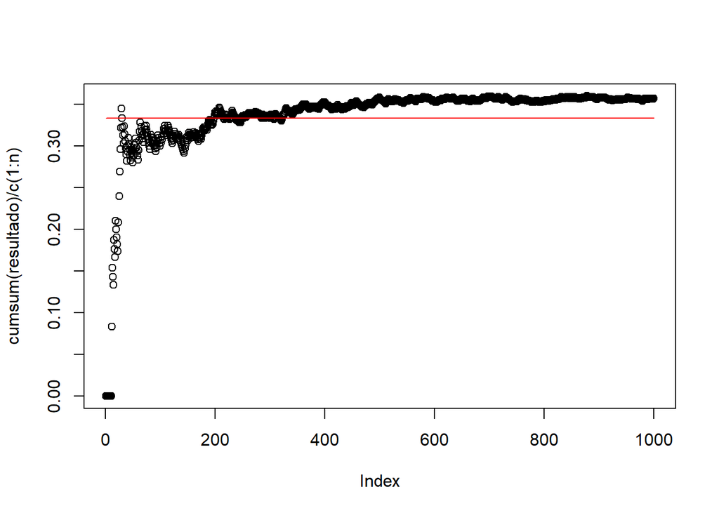

```r
plot(cumsum(resultado)/c(1: n))
lines(rep(1/3, n), col = 'red')
```